# Modeling policy interventions

18 November 2020

## Intro

## Agenda

- Intro
- Talk about some stuff
- Outro

## Introductions

- Name
- Background in econometrics vs biostats
- Where you were before CHSE
- Favorite movie

## Panel data

## Rando example

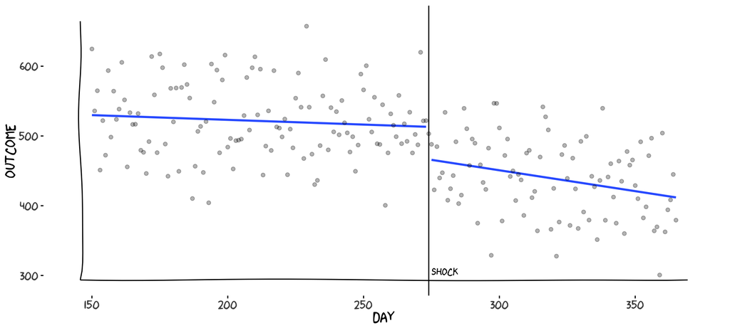

## Impact of a policy intervention

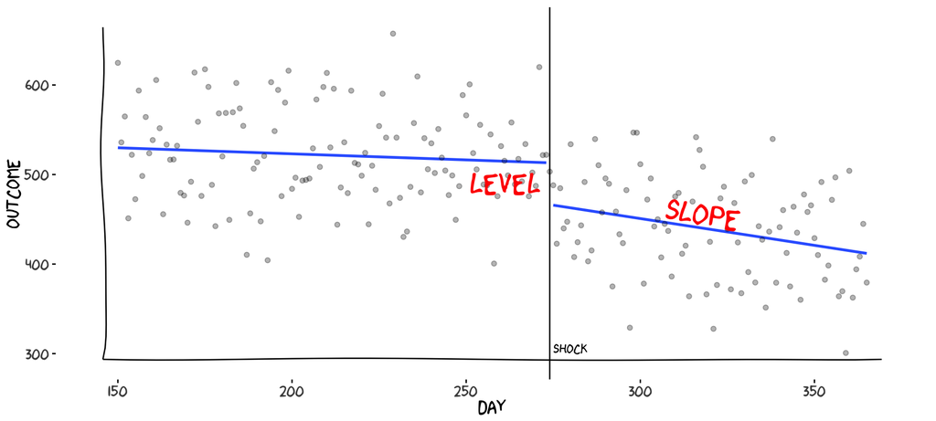

## Framing the question

## What is the research question?

- How does the policy affect outcomes among the treated in the post-intervention era?
- How does the policy affect outcomes among the treated in *this particular part* of the post-intervention era?

## Notation

\[ \begin{align} Y(t) ~~&|~~ \mbox{Observed outcome at time } t \\ D = 0 ~~&|~~ \mbox{Control} \\ D = 1 ~~&|~~ \mbox{Treated} \\ t = 1, \ldots, T_0 ~~&|~~ \mbox{Pre-intervention times} \\ t = T_0 + 1, \ldots, T ~~&|~~ \mbox{Post-intervention times} \\ Y^d(t) ~~&|~~ \mbox{Potential outcome with treatment } D=d \mbox{ at time } t \end{align} \]

## Counterfactual framework

**Two parallel universes**

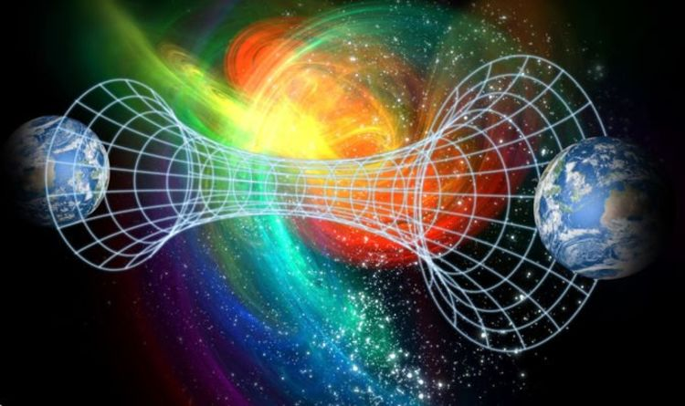

- one where the intervention occurred
- one where the intervention did not occur

Policy effect = difference between the outcomes in those two universes

## Average treatment effect on the treated (ATT)

**Estimand:** \[ ATT = E[Y^1 - Y^0 | D = 1] \]

**Estimator:**

Depends on the research question and on what data are available

## Application: Terraforming LV-426

## Hadley’s Hope

[figure not shown]

LV-426

## Broad research question

> What effect does this policy intervention have on monthly operating costs?

## Some strategies

Increasing level of sophistication:

- Pre/post test
- Interrupted time series (ITS)
- Comparative ITS
- Difference in differences

## Data-generating function

This slide needs work.

The point is that the true ATE should be -25.

hh <- tibble(Date = rep(seq(ymd(“2174-01-01”), ymd(“2178-12-31”), by=“month”), times=2), time = rep(1:60, times=2), weather_index = runif(n=120, min=0, max=10)) %>% mutate(colony = rep(c(“Hadley’s Hope”, “Fiorina 161”), each=nrow(.)/2), post = time > intervention, y = 500 + (100 * as.numeric(colony==“Hadley’s Hope”)) + (3 * time) + (-25 * as.numeric((colony==“Hadley’s Hope” & post))) + (-2 * post * as.numeric(colony==“Hadley’s Hope”) * (time-31)) + (5 * weather_index) + rnorm(n=nrow(.), mean=0, sd=20))

## Comparing pre/post means

## Operating costs over time

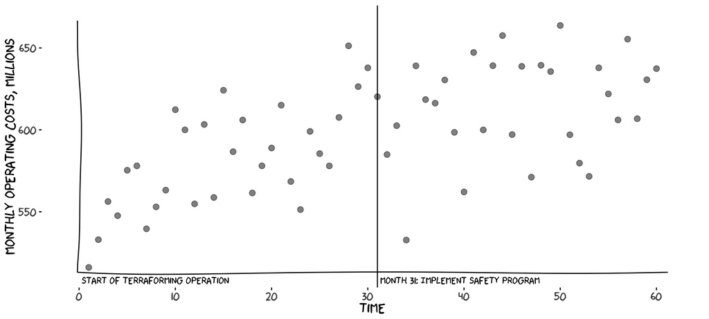

## Compare means

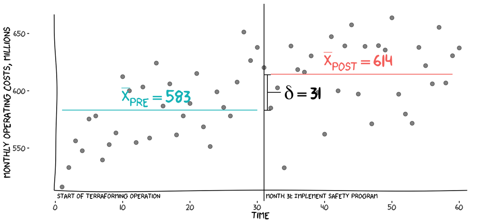

## ATT

\[ \begin{align} ATT =& E[Y^1 - Y^0 | D = 1] \\ =& E[Y^1 | D = 1] - E[Y^0 | D = 1] \end{align} \] \(E[Y^0 | D = 1]\) is in the other universe, so assume

\[ \begin{align} E[Y^0 | D = 1] &= E[Y^0(t > T_0) | D = 1] \\ &= E[Y^1(t \le T_0) | D = 1] \end{align} \]

## ATT

Then

\[ \begin{align} ATT &= E[Y^1 - Y^0 | D = 1] \\ &= E[Y^1 | D = 1] - E[Y^0 | D = 1] \\ &= E[Y^1(t > T_0) | D = 1] - E[Y^0(t > T_0) | D = 1] \\ &= E[Y^1(t > T_0) | D = 1] - E[Y^1(t < T_0) | D = 1] \\ & = \bar{X}_{t > T_0} - \bar{X}_{t < T_0} \end{align} \]

## t-test

\[ t = \frac{\bar{X}_{post} - \bar{X}_{pre}}{s \sqrt{\frac{2}{n}}} \]

```r
mean(hh$y[hh$post==1]) - mean(hh$y[hh$post==0])
with(hh, t.test(y ~ post))
```

```
## [1] 31.31477
##
##  Welch Two Sample t-test
##
## data:  y by post
## t = -3.7687, df = 57.917, p-value = 0.0003867
## alternative hypothesis: true difference in means is not equal to 0
## 95 percent confidence interval:
##  -47.94785 -14.68169
## sample estimates:
## mean in group 0 mean in group 1
##        583.1383        614.4531
```

## OLS

Similarly, \[ Y = \beta_0 + \beta_1 \mbox{POST} + \mathbf{\beta_x X} + \varepsilon \]

```r
lm_prepost <- lm(y ~ post + weather_index,
           data=hh)
```

```
## # A tibble: 3 x 5
##   term          estimate std.error statistic p.value
##   <chr>            <dbl>     <dbl>     <dbl> <chr>
## 1 (Intercept)     553.        9.42     58.7  <0.001
## 2 post             38.5       7.71      4.99 <0.001
## 3 weather_index     5.11      1.34      3.83 <0.001
```

## Comparing pre/post means

**Assumptions:**

- Outcomes would stay the same over time in the absence of the intervention
- No unmeasured confounding

**Accounts for:**

- Baseline value for outcomes

**Does not account for:**

- Outcome was already getting better or worse
- Anything that changed outcomes unrelated to the intervention

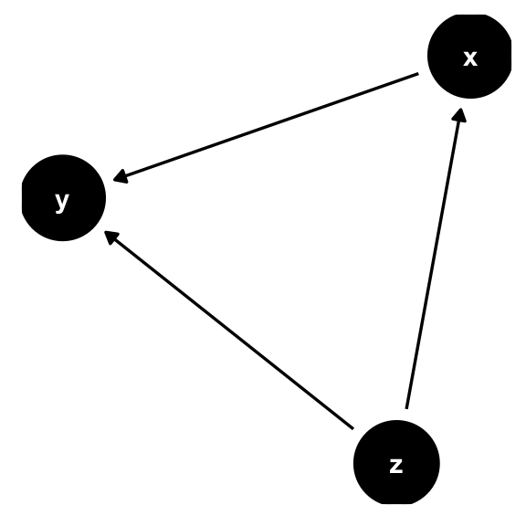

## Interrupted time series

## Operating costs over time

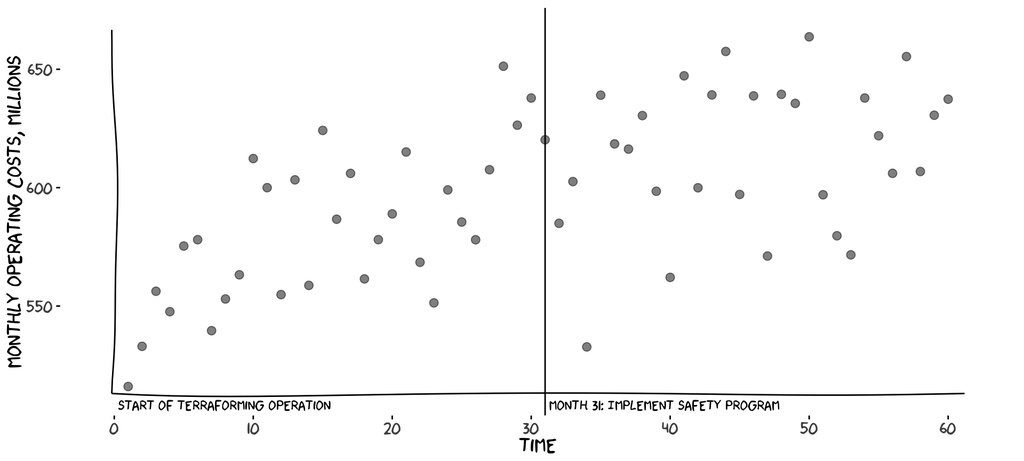

## Change in level

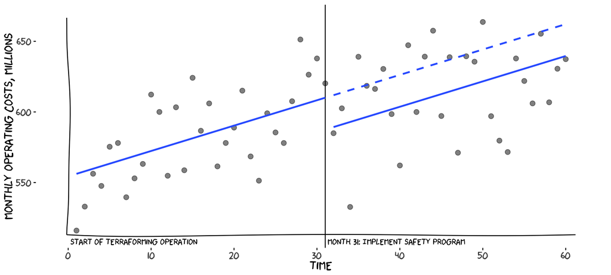

## Change in level

\[ \begin{align} \mbox{Compare means:} ~~|&~~ Y = \beta_0 + \beta_1 POST + \varepsilon \\ \mbox{ITS (level):} ~~|&~~ Y_{t} = \beta_0 + \beta_1 \mbox{TIME} + \beta_2 \mbox{POST} + \varepsilon_t\\ \end{align} \]

\[ \begin{align} ATT &= E[Y^1 - Y^0 | D = 1] \\ &= E[Y^1 | D = 1] - E[Y^0 | D = 1] \\ & = \beta_2 \end{align} \]

## Linear model

```r
lm_its <- lm(y ~ t + post,
             data = hh)
```

```
## # A tibble: 3 x 5
##   term        estimate std.error statistic p.value
##   <chr>          <dbl>     <dbl>     <dbl> <chr>
## 1 (Intercept)   610.       8.10      75.3  <0.001
## 2 t               1.80     0.421      4.27 <0.001
## 3 post          -22.6     14.6       -1.55 0.127
```

## Change in level and slope

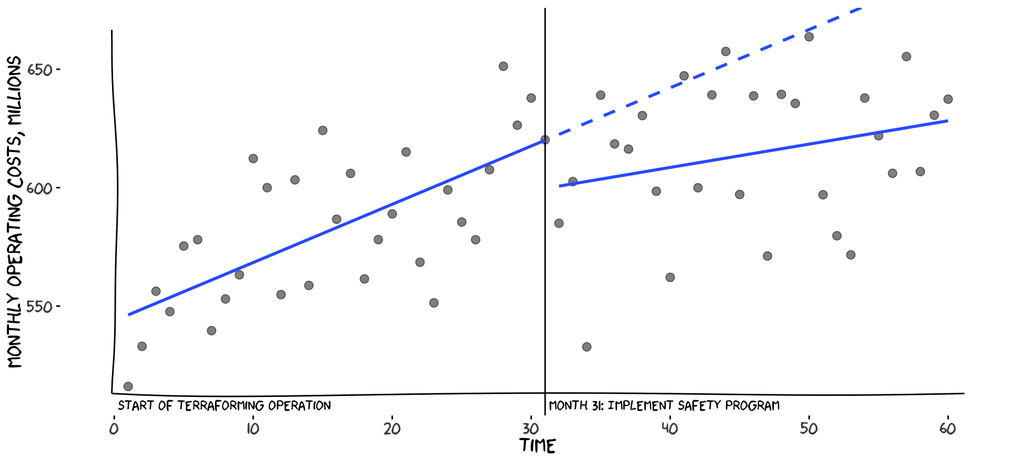

## Change in level and slope

### Linear model

\[ \begin{align} \mbox{Compare means:} ~~|&~~ Y = \beta_0 + \beta_1 POST + \varepsilon \\ \mbox{ITS (level):} ~~|&~~ Y_{t} = \beta_0 + \beta_1 \mbox{TIME} + \beta_2 \mbox{POST} + \varepsilon_t\\ \mbox{ITS (level & slope):} ~~|&~~ Y_{t} = \beta_0 + \beta_1 \mbox{TIME} + \beta_2 \mbox{POST} + \beta_3 \mbox{TIME} \times \mbox{POST} + \varepsilon_t\\ \end{align} \]

## ATT

\[ Y_{t} = \beta_0 + \beta_1 \mbox{TIME} + \beta_2 \mbox{POST} + \beta_3 \mbox{TIME} \times \mbox{POST} + \varepsilon_t \]

So for any \(t \in T \ge T_0\),

\[ \begin{align} ATT(t) &= E[Y^1(t) - Y^0(t) | D = 1] \\ &= E[Y^1(t) | D = 1] - E[Y^0(t) | D = 1] \\ & = \beta_2 + (\beta_3 \times t) \end{align} \]

## Change in level and slope

### Linear model

```r
lm_its2 <- lm(y ~ t*post,
             data = hh)
```

```
## # A tibble: 4 x 5
##   term        estimate std.error statistic p.value
##   <chr>          <dbl>     <dbl>     <dbl> <chr>
## 1 (Intercept)   620.       9.73      63.7  <0.001
## 2 t               2.46     0.557      4.41 <0.001
## 3 post          -20.4     14.4       -1.42 0.162
## 4 t:post         -1.47     0.831     -1.77 0.081
```

## Comparative methods

## Fiorina 161

[figure not shown]

Fiorina 161, Outer Veil

## Fiorina 161 and Hadley’s Hope

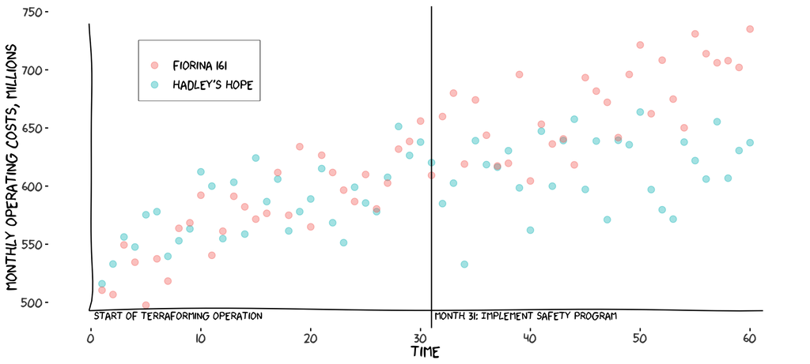

## Two-group post-mean comparison

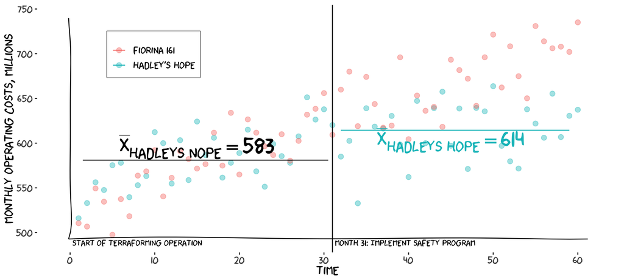

## Two-group post-mean comparison

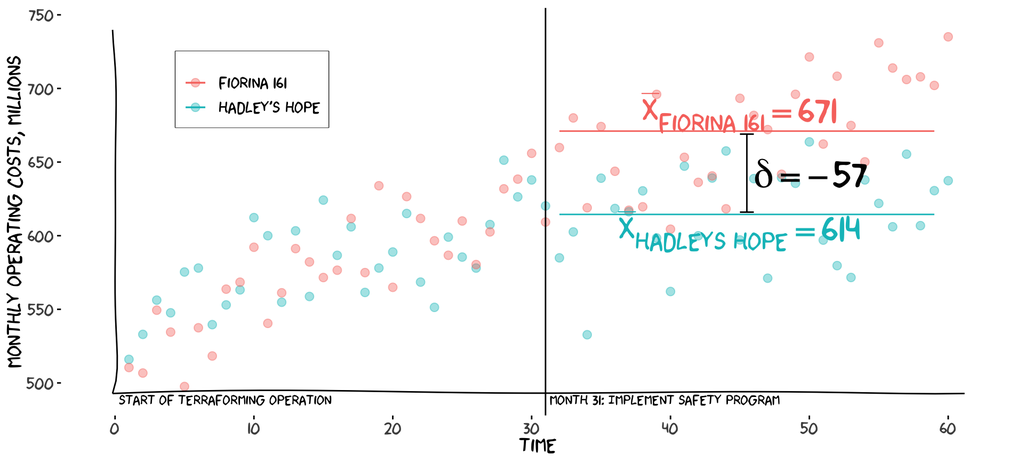

## Two-group post-mean comparison

\[ t = \frac{\bar{X}_{test} - \bar{X}_{comparison}}{s \sqrt{\frac{2}{n}}} \]

```r
mean(hhf$y[hhf$treat==1]) - mean(hhf$y[hhf$treat==0])
```

```
## [1] -25.02059
```

```r
with(hhf, t.test(y ~ post))
```

```
##
##  Welch Two Sample t-test
##
## data:  y by post
## t = -8.2551, df = 110.6, p-value = 3.575e-13
## alternative hypothesis: true difference in means is not equal to 0
## 95 percent confidence interval:
##  -76.71067 -47.01124
## sample estimates:
## mean in group 0 mean in group 1
##        580.8846        642.7455
```

## Two-group post-mean comparison

\[ Y = \beta_0 + \beta_1 \mbox{TREAT} + \mathbf{\beta_x X} + \varepsilon \]

```r
lm_2grp <- lm(y ~ treat + weather_index,
           data=hhf %>% filter(post==1))
```

```
##
##
## |term          |  estimate| std.error| statistic|p.value |
## |:-------------|---------:|---------:|---------:|:-------|
## |(Intercept)   | 642.20137|  8.504821| 75.510272|<0.001  |
## |treat         | -56.03877|  7.861046| -7.128666|<0.001  |
## |weather_index |   6.30736|  1.408055|  4.479483|<0.001  |
```

## Two-group post-mean comparison

- **Assumes** outcomes for the two groups would be the same if neither or both received the intervention
- **Accounts for** anything unrelated to the intervention that changed outcomes equally for both groups
- **Does not account for** any baseline differences in levels or slopes between the two groups or non-intervention *shocks* that affected only one group

## Difference in differences

## Fiorina 161 and Hadley’s Hope

[figure not shown]

## Difference in differences

- **Assumes** longitudinal trends in the pre-intervention period are parallel between groups ### Update this language to reflect that one web site– “Counterfactual assumption”
  - Parallel trends
  - Common shocks
- **Accounts for** baseline differences in outcomes between the two groups and shocks unrelated to the intervention that affected both groups
- **Does not account for** Shocks unrelated to the intervention that only occurred in one group or differences between groups in the longitudinal trajectory before the intervention

## ATT

## CITS

\[ \begin{align} Y =& \beta_0 + \beta_1 \mbox{TIME} + \beta_2 \mbox{POST} + \beta_3 \mbox{POST} \times \mbox{TIME} + \\ & \beta_4 \mbox{TREAT} + \beta_5 \mbox{TREAT} \times \mbox{TIME } + \\ & \beta_6 \mbox{TREAT} \times \mbox{POST} + \\ & \beta_7 \mbox{TREAT} \times \mbox{POST} \times \mbox{TIME} + \varepsilon_t \end{align} \]

where \[ \mbox{TIME } = \mbox{ {1, ... 60}},\\ \mbox{POST } = \begin{cases} 0 \mbox{ if TIME} \le 31, \\ 1 \mbox{ if TIME > 31}\\ \end{cases},\\ \mbox{TREAT } = \begin{cases} 0 \mbox{ = Fiorina 161}, \\ 1 \mbox{ = Hadley's Hope} \end{cases} \]

```r
lm_cits <- lm(y ~ time*post + time*treat + treat*post + I(treat * post * time),
             data = hhf)
```

```
## # A tibble: 8 x 5
##   term                   estimate std.error statistic p.value
##   <chr>                     <dbl>     <dbl>     <dbl> <chr>
## 1 (Intercept)             518.        9.85    52.6    <0.001
## 2 time                      3.79      0.537    7.06   <0.001
## 3 post                     22.1      29.5      0.750  0.455
## 4 treat                    25.8      13.9      1.85   0.067
## 5 I(treat * post * time)   -0.530     1.13    -0.468  0.641
## 6 time:post                -0.944     0.801   -1.18   0.241
## 7 time:treat               -1.33      0.760   -1.75   0.082
## 8 post:treat                3.24     41.7      0.0778 0.938
```

## Comparative interrupted time series

## Diff-in-Diff

## Some econometrics

## Fixed effects

## Clustered standard errors

## Marginal effects

## Propensity scores

How to speak to an economist ## Endogeneity